[figure not shown]

*I Workshop de Análise de Dados Entomológicos*

*01/06/2021*

# Modelos lineares generalizados para dados de contagem e dados inflacionados de zero

**Prof. Anderson Rodrigo da Silva** - [IF Goiano](https://www.ifgoiano.edu.br/home/index.php/urutai)

## Superdispersão

**Significado:** quando o modelo não captura o suficiente da variabilidade contida nos dados $y$.

**Causas:**

- Ausência de termos importantes no modelo (mal especificação);
- Escolha inapropriada da distribuição e/ou da função de ligação (GLM);
- Presença de *outliers*;
- Correlação nas observações $y$;
- Excesso de zeros, etc.

**Distribuições sucetíveis:**

- Poisson, em que $Var(y)=E(y)$;
- Binomial, em que $Var(y)<E(y)$;
- Normal, em que $Var(y)$ é constante.

**Distribuições apropriadas (ou menos suscetíveis):**

- Binomial negativa/Geométrica;
- Gamma;
- Normal inversa

## Exemplo de aplicação

Eficácia de tratamentos inseticidas no controle de *Tuta absoluta* em tomate, num experimento inteiramente casualizado com quatro repetições.

[figure not shown]

*Foto: Estebam Sani (fonte: Embrapa Hortaliças)*

### Dados experimentais

Reposta (y): número frutos danificados por parcela

```r
y = c(0, 0, 1, 0,  0, 3, 3, 5,  1, 0, 0, 0,  8, 1, 0, 7)
Trat = gl(4, 4, labels = LETTERS[1:4])
Trat
```

1. A

2. A

3. A

4. A

5. B

6. B

7. B

8. B

9. C

10. C

11. C

12. C

13. D

14. D

15. D

16. D

1. 'A'

2. 'B'

3. 'C'

4. 'D'

### Frequência relativa observada *vs.* freq. pelo modelo Poisson

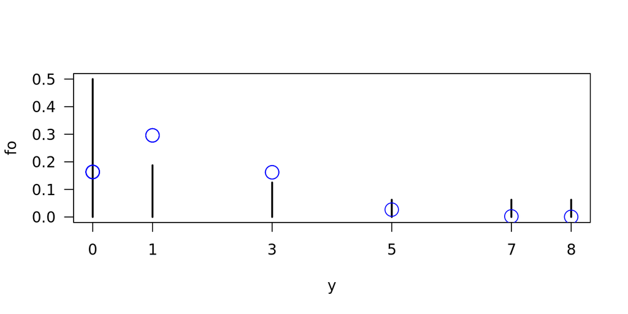

```r
fo = table(y)/length(y)                   # amostral
fm = dpois(y, lambda = mean(y))           # pelo modelo
plot(fo, las = 1)
points(x = y, y = fm, col = "blue", cex = 2)
```

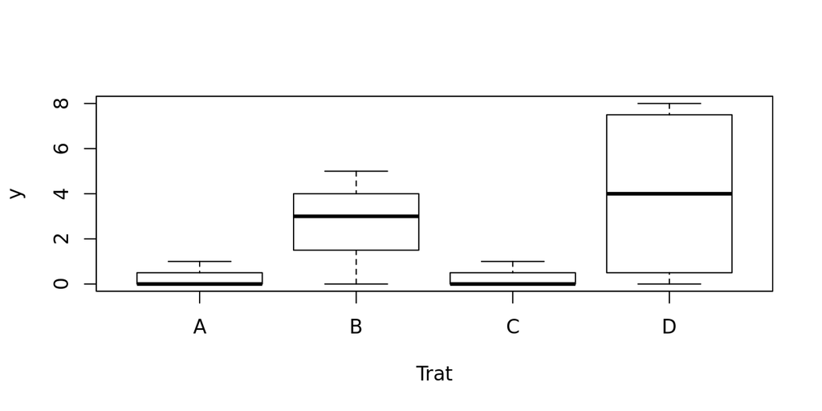

```r
boxplot(y ~ Trat)
```

## LM *versus* GLM

Modelo de ANOVA para um fator:

\begin{eqnarray*} y_{ij} & = & \mu_{ij} + \epsilon_{ij} \\ & = & \mu + t_i + \epsilon_{ij} \end{eqnarray*}

Modelo de ANODEV para um fator:

\begin{eqnarray*} y_{ij} & = & g^{-1} (\mu_{ij})+ \epsilon_{ij} \\ & = & g^{-1}(\mu + t_i) + \epsilon_{ij} \end{eqnarray*}

sendo $g(\mu)$ a função de ligação. Ex: GLM Poisson: $y_{ij} = \exp(\mu + t_i) + \epsilon_{ij}$

### ANOVA

```r
mod.normal = lm(y ~ Trat)
anova(mod.normal)
```

A anova: 2 × 5

|  | Df <int> | Sum Sq <dbl> | Mean Sq <dbl> | F value <dbl> | Pr(>F) <dbl> |
| --- | --- | --- | --- | --- | --- |
| Trat | 3 | 42.1875 | 14.062500 | 2.626459 | 0.09829004 |
| Residuals | 12 | 64.2500 | 5.354167 | NA | NA |

### GLM Poisson

```r
mod.poisson = glm(y ~ Trat, family = poisson)
summary(mod.poisson)
```

```
Call:
glm(formula = y ~ Trat, family = poisson)

Deviance Residuals:
    Min       1Q   Median       3Q      Max
-2.8284  -0.7071  -0.7071   1.1281   1.7579

Coefficients:
              Estimate Std. Error z value Pr(>|z|)
(Intercept) -1.386e+00  9.999e-01  -1.386  0.16563
TratB        2.398e+00  1.044e+00   2.296  0.02168 *
TratC        4.569e-16  1.414e+00   0.000  1.00000
TratD        2.773e+00  1.031e+00   2.690  0.00715 **
---
Signif. codes:  0 ‘***’ 0.001 ‘**’ 0.01 ‘*’ 0.05 ‘.’ 0.1 ‘ ’ 1

(Dispersion parameter for poisson family taken to be 1)

    Null deviance: 55.299  on 15  degrees of freedom
Residual deviance: 28.720  on 12  degrees of freedom
AIC: 59.93

Number of Fisher Scoring iterations: 5
```

### ANODEV

```r
anova(mod.poisson, test = "Chisq")
```

A anova: 2 × 5

|  | Df <int> | Deviance <dbl> | Resid. Df <int> | Resid. Dev <dbl> | Pr(>Chi) <dbl> |
| --- | --- | --- | --- | --- | --- |
| NULL | NA | NA | 15 | 55.29852 | NA |
| Trat | 3 | 26.57845 | 12 | 28.72007 | 7.215593e-06 |

### Comparando os modelos por AIC (*menor é melhor*)

```r
AIC(mod.normal, mod.poisson)
```

A data.frame: 2 × 2

|  | df <dbl> | AIC <dbl> |
| --- | --- | --- |
| mod.normal | 5 | 77.64912 |
| mod.poisson | 4 | 59.93009 |

### Mas o GLM Poisson conseguiu capturar de forma eficaz a variabilidade contida nos dados?

```r
se = function(x) se = sqrt(var(x)/length(x))
s = aggregate(y ~ Trat, FUN = se)                           # amostral
library(emmeans)
med.n = lsmeans(mod.normal, "Trat", type = "response")      # pelo modelo
med.p = lsmeans(mod.poisson, "Trat", type = "response")     # pelo modelo
cat("\nSE(obs.):", round(s$y, 2))
med.n
med.p
```

```
SE(obs.): 0.25 1.03 0.25 2.04
```

```
 Trat lsmean   SE df lower.CL upper.CL
 A      0.25 1.16 12   -2.271     2.77
 B      2.75 1.16 12    0.229     5.27
 C      0.25 1.16 12   -2.271     2.77
 D      4.00 1.16 12    1.479     6.52

Confidence level used: 0.95
```

```
 Trat rate    SE  df asymp.LCL asymp.UCL
 A    0.25 0.250 Inf    0.0352      1.77
 B    2.75 0.829 Inf    1.5230      4.97
 C    0.25 0.250 Inf    0.0352      1.77
 D    4.00 1.000 Inf    2.4505      6.53

Confidence level used: 0.95
Intervals are back-transformed from the log scale
```

### Um teste de superdispersão

```r
rP = residuals(mod.poisson, type = "pearson")                # res. de Pearson
X2 = sum(rP^2)                                               # qui-quad. de Pearson
X2/mod.poisson$df.residual                                   # par. dispersão
pchisq(X2, df = mod.poisson$df.residual, lower.tail = FALSE) # p-valor
```

1.92803029835239

0.026590314937887

## GLM 'ZIP' (*Zero-Inflated Poisson*)

Especificação do modelo:

\begin{equation} \nonumber \begin{array}{l} \log(\mu_{ij}) = \mu + t_i \\ logito(p_{ij}) = W\gamma \end{array} \end{equation}

isto é,

\begin{equation} \nonumber \begin{array}{l} y_{ij} = \exp(\mu + t_i) + \epsilon_{ij} \\ p_{ij} = \frac{\exp(W\gamma)}{1 + \exp(W\gamma)} \end{array} \end{equation}

$W$ define os fatores do modelo que supostamente ocasionam o excesso de zero ($p_{ij}$).

### Capturando superdispersão com ZIP:

Média e variância:

```r
library(pscl)
mod.zip = zeroinfl(y ~ Trat | 1, dist = "poisson")
summary(mod.zip)
```

```
Call:
zeroinfl(formula = y ~ Trat | 1, dist = "poisson")

Pearson residuals:
    Min      1Q  Median      3Q     Max
-1.3673 -0.4795 -0.4795  0.9738  1.4661

Count model coefficients (poisson with log link):
              Estimate Std. Error z value Pr(>|z|)
(Intercept) -1.145e+00  1.048e+00  -1.093   0.2745
TratB        2.415e+00  1.091e+00   2.214   0.0268 *
TratC       -2.978e-05  1.460e+00   0.000   1.0000
TratD        2.813e+00  1.077e+00   2.612   0.0090 **

Zero-inflation model coefficients (binomial with logit link):
            Estimate Std. Error z value Pr(>|z|)
(Intercept)  -1.2329     0.8503   -1.45    0.147
---
Signif. codes:  0 '***' 0.001 '**' 0.01 '*' 0.05 '.' 0.1 ' ' 1

Number of iterations in BFGS optimization: 12
Log-likelihood: -22.69 on 5 Df
```

### Probabilidade de excesso de zeros:

```r
exp(-1.233)/(1 + exp(-1.233))
```

0.225656786926418

### Ainda há superdispersão?

```r
rP = residuals(mod.zip, type = "pearson")                  # res. de Pearson
X2 = sum(rP^2)                                             # qui-quad. de Pearson
X2/mod.zip$df.residual
pchisq(X2, df = mod.zip$df.residual, lower.tail = FALSE)   # p-valor
```

1.25356169628348

0.244879403178459

### Comparando os três modelos

```r
AIC(mod.normal, mod.poisson, mod.zip)
```

A data.frame: 3 × 2

|  | df <dbl> | AIC <dbl> |
| --- | --- | --- |
| mod.normal | 5 | 77.64912 |
| mod.poisson | 4 | 59.93009 |
| mod.zip | 5 | 55.38440 |

```r
cat("\nSE(obs.):", round(s$y, 3))                     # erros-padrão amostrais
med.z = lsmeans(mod.zip, "Trat", type = "response")
med.z
```

```
SE(obs.): 0.25 1.031 0.25 2.041
```

```
 Trat lsmean    SE  df asymp.LCL asymp.UCL
 A     0.246 0.255 Inf    -0.252     0.745
 B     2.758 0.988 Inf     0.822     4.693
 C     0.246 0.255 Inf    -0.252     0.745
 D     4.107 1.295 Inf     1.569     6.644

Confidence level used: 0.95
```

### Intervalos de 95% de confiança

```r
options(repr.plot.width = 9, repr.plot.height = 3, repr.plot.res = 200)
```

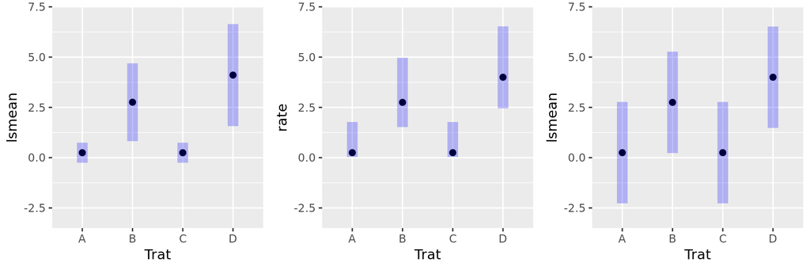

```r
library(ggplot2); library(gridExtra)
p1 = plot(med.z, horizontal = FALSE) + ylim(-3, 7)
p2 = plot(med.p, horizontal = FALSE) + ylim(-3, 7)
p3 = plot(med.n, horizontal = FALSE) + ylim(-3, 7)
grid.arrange(p1, p2, p3, ncol = 3)
```

## Alternativas para lidar com superdispersão/inflação de zeros

- GLM binomial negativo
- Modelo ZINB (*Zero-Inflated Negative Binomial*)
- Modelos de barreiras (*hurdle models*)
- Modelo misto
- GAMLSS

[figure not shown]

# Obrigado!

anderson.silva@ifgoiano.edu.br